# Homework 5: Binomial GLMs

Jamie Ash

due: 2021-09-29

Let’s consider some data on the prevalence of avian pox among birds on Hawaiʻi island. In the attached paper the researchers investigated the prevalence of the disease at twelve sites in windward rainforests, over a range of altitudes, in four bird species – three endemic (ʻApapane, Hawaiʻi ʻAmakihi, ʻIʻiwi) and one introduced (Japanese White-eye). Individual birds were assayed for active pox infection (lesions), as well as chronic malaria infection (birds that survive malaria become chronically infected). ʻIʻiwi is highly susceptible to malaria, while ʻApapane and Hawaiʻi ʻAmakihi are moderately susceptible, and the White-eye is resistant.

# 1 Display malaria in birds

The twelve sites have been coded as low/medium/high elevation. First, summarize the number of observations of each bird species at each elevation. This will be important context for what we can and cannot ask about avian pox patterns. Also, what is the prevalence of chronic malaria in the bird species at the difference elevations? Note that some birds do not have a known malaria status (code = 2). Only use birds with code = 0 or 1 to quantify the prevalence of malaria.

```r
birds  <- read.csv(paste(infile, "Pox_Data_revised.csv",
                         sep = ""))
birds[birds$Malaria == 2, "Malaria"] <- NA

birds$x <- rep(1, nrow(birds))
elev  <- aggregate(birds$x,
                   by = list(Species = birds$Species, Elev = birds$Elev),
                   FUN = sum)
colnames(elev) <- c("Species", "Elev", "pop")

known <- subset(birds, !Malaria == 2)
sick_birds <- aggregate(known$Malaria,
                   by = list(Species = known$Species, Elev = known$Elev),
                   FUN = sum)
all_birds  <- aggregate(known$x,
                   by = list(Species = known$Species, Elev = known$Elev),
                   FUN = sum)

all_birds$mal_per <- round((sick_birds$x / all_birds$x) * 100, 0)
all_birds$mal_per <- paste(all_birds$mal_per, "%", sep = "")

mydata <- merge(elev, all_birds, by=c("Species", "Elev"), all = TRUE)
mydata[is.na(mydata$mal_per), ]$mal_per <- "NA"
```

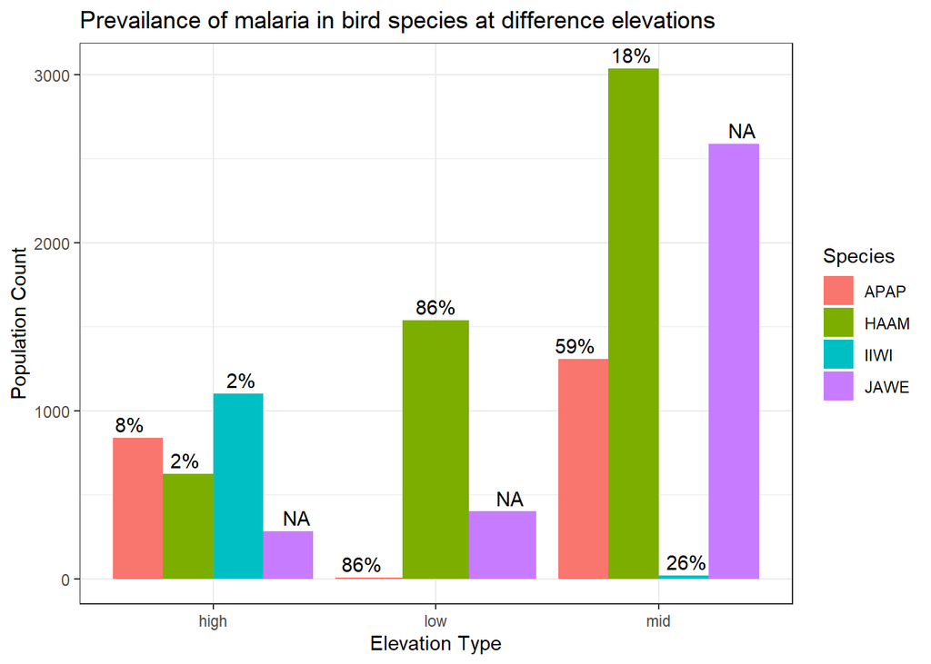

Figure 1.1: Population of four bird species, Apapane (APAP), Hawaii Amakihi (HAAM), Iiwi (IIWI) and Japanese White-eye (JAWE) at three different elevations: low, mid, and high. The respective malaria infection rates are displayed above each bird’s population bar.

```r
ggplot(mydata, aes(fill = Species, y = pop, x = Elev)) +
  geom_bar(position = "dodge", stat = "identity") +
  geom_text(aes(y = pop, label = mal_per),
            vjust = -0.4,
            position = position_dodge(width = 1)) +
  labs(title = "Prevailance of malaria in bird species at difference elevations") +
  xlab("Elevation Type") +
  ylab("Population Count") +
  theme_bw()
```

# 2 Pox birds without considering malaria

Create a model where the presence/absence of pox can differ between species and between elevations. Allow the effect of elevation to differ between species. Make an effects plot of the fitted model and perform likelihood ratio tests on the predictors. Provide a verbal explanation of what the model tells us. Look at summary() of the model, and note that there is an NA for one of the coefficients. Why do you think this is?

## 2.1 Answer

Using a general linear model with a binomial family, and a type two Anova() likelihood test I found that there is a significant relationship between birds with pox and bird species. I also found that there was a significant relationship between the effect of bird species on pox infection and elevation, as well as a significant direct relationship between pox infection and elevation. Because there are no Iiwi found at low elevations, the effects an NA is received for the Iwwi low coefficient. I ran a model (mod2) without the direct elevation interaction on pox infection and only Elev:Species, so that nice effects plots could be made. Lastly I combined active pox occurrences with old pox occurrences because I don’t see why not, pox are pox.

### 2.1.1 Summary Statistics

```r
birds  <- read.csv(paste(infile, "Pox_Data_revised.csv",
                         sep = ""))

# Combining Active pox and Old Pox
birds$pox <- birds$Activepox + birds$Oldpox
birds[birds$pox == 2, "pox"] <- 1

# model to observe the Anova results
mod  = glm(pox ~ Species + Elev + Elev:Species, data = birds, family = binomial)
# model to plot the effects
mod2 = glm(pox ~ Species + Elev:Species, data = birds, family = binomial)

summary(mod)
```

```
##
## Call:
## glm(formula = pox ~ Species + Elev + Elev:Species, family = binomial,
##     data = birds)
##
## Deviance Residuals:
##     Min       1Q   Median       3Q      Max
## -0.8750  -0.3486  -0.2580  -0.1720   3.4616
##
## Coefficients: (1 not defined because of singularities)
##                     Estimate Std. Error z value Pr(>|z|)
## (Intercept)          -3.6146     0.2161 -16.730  < 2e-16 ***
## SpeciesHAAM           0.2084     0.3136   0.665  0.50630
## SpeciesIIWI           0.2283     0.2746   0.832  0.40567
## SpeciesJAWE          -2.0273     1.0248  -1.978  0.04790 *
## Elevlow               2.6983     0.8641   3.123  0.00179 **
## Elevmid               2.8518     0.2241  12.728  < 2e-16 ***
## SpeciesHAAM:Elevlow  -1.9694     0.8995  -2.189  0.02857 *
## SpeciesIIWI:Elevlow       NA         NA      NA       NA
## SpeciesJAWE:Elevlow  -3.0454     1.6590  -1.836  0.06641 .
## SpeciesHAAM:Elevmid  -2.2161     0.3283  -6.750 1.48e-11 ***
## SpeciesIIWI:Elevmid  -0.5642     0.5879  -0.960  0.33722
## SpeciesJAWE:Elevmid  -1.4158     1.0394  -1.362  0.17318
## ---
## Signif. codes:  0 '***' 0.001 '**' 0.01 '*' 0.05 '.' 0.1 ' ' 1
##
## (Dispersion parameter for binomial family taken to be 1)
##
##     Null deviance: 5941.4  on 11742  degrees of freedom
## Residual deviance: 4883.5  on 11732  degrees of freedom
## AIC: 4905.5
##
## Number of Fisher Scoring iterations: 8
```

```r
Anova(mod, type = 2)
```

```
## Analysis of Deviance Table (Type II tests)
##
## Response: pox
##              LR Chisq Df Pr(>Chisq)
## Species        856.56  3  < 2.2e-16 ***
## Elev           318.35  2  < 2.2e-16 ***
## Species:Elev    45.29  5  1.267e-08 ***
## ---
## Signif. codes:  0 '***' 0.001 '**' 0.01 '*' 0.05 '.' 0.1 ' ' 1
```

### 2.1.2 Effects Figures

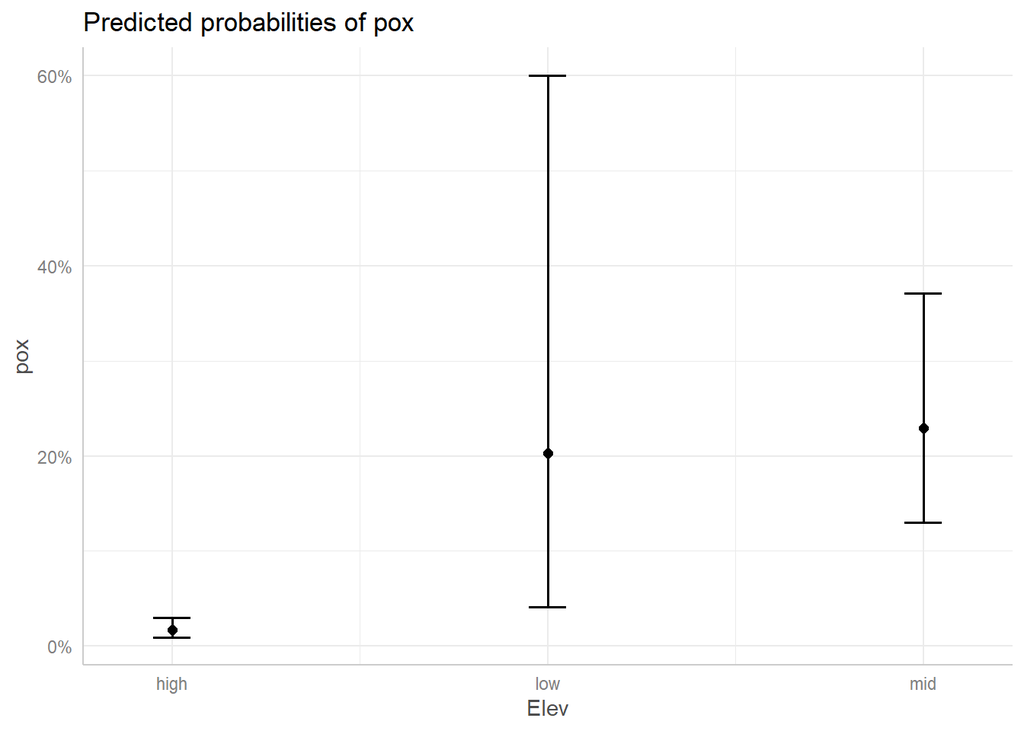

```r
plot(ggeffect(mod2, terms ="Elev"))
```

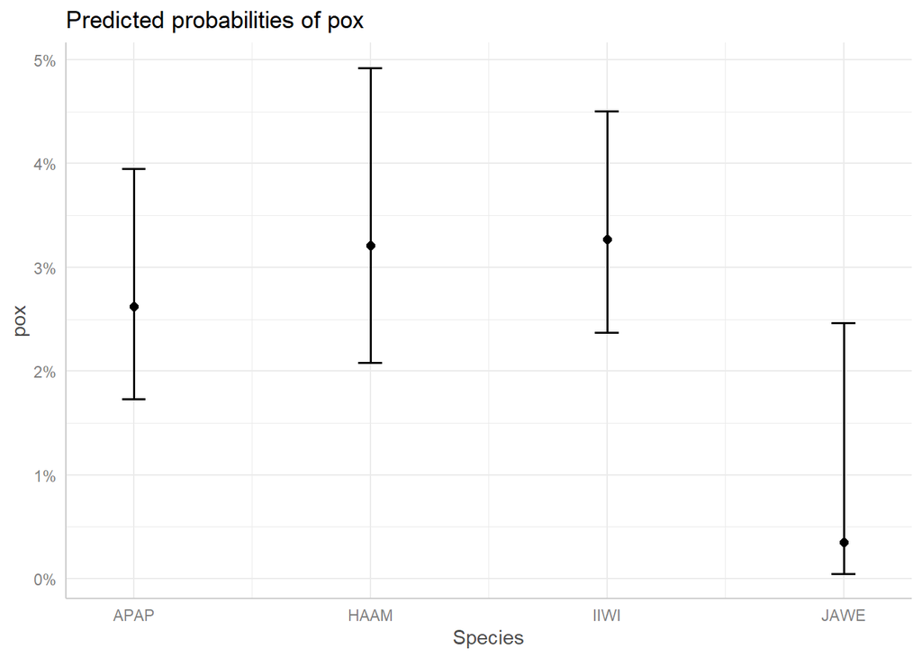

```r
plot(ggeffect(mod2, terms ="Species"))
```

# 3 Pox birds removing Malaria birds

Create a subset of the data that only includes birds with known malaria status (0 or 1). Also, you’ll want to exclude ʻIʻiwi from this model (look at your answer to #1 to see why). Create a model where pox prevalence varies by species, elevation, and malaria status, and where the effect of elevation and the effect of malaria status can differ between species. Make effects plots and perform likelihood ratio tests on the predictors. Provide your interpretation of what the results mean.

```r
birds  <- read.csv(paste(infile, "Pox_Data_revised.csv",
                         sep = ""))

birds$pox <- birds$Activepox + birds$Oldpox
birds[birds$pox == 2, "pox"] <- 1

birds[birds$Malaria == 2, "Malaria"] <- NA
birds <- subset(birds, !is.na(Malaria))
birds <- subset(birds, !Species == "IIWI")

mod = glm(pox ~ Species + Elev + Elev:Species + Malaria + Malaria:Species,
          data   = birds,
          family = "binomial")

disp <- sum(residuals(mod, type = "pearson")^2)/(nrow(birds) - length(coef(mod)))
```

## 3.1 Answer

### 3.1.1 Summary Statistics

```r
summary(mod)
```

```
##
## Call:
## glm(formula = pox ~ Species + Elev + Elev:Species + Malaria +
##     Malaria:Species, family = "binomial", data = birds)
##
## Deviance Residuals:
##     Min       1Q   Median       3Q      Max
## -1.1534  -0.3989  -0.2921  -0.2675   2.8308
##
## Coefficients:
##                     Estimate Std. Error z value Pr(>|z|)
## (Intercept)          -3.9884     0.2374 -16.797  < 2e-16 ***
## SpeciesHAAM           0.6762     0.3337   2.027 0.042708 *
## Elevlow               1.1445     0.8911   1.284 0.199034
## Elevmid               1.8225     0.2499   7.294 3.02e-13 ***
## Malaria               2.1093     0.1559  13.527  < 2e-16 ***
## SpeciesHAAM:Elevlow  -1.6868     0.9382  -1.798 0.072205 .
## SpeciesHAAM:Elevmid  -1.6433     0.3559  -4.617 3.90e-06 ***
## SpeciesHAAM:Malaria  -0.7462     0.2205  -3.383 0.000716 ***
## ---
## Signif. codes:  0 '***' 0.001 '**' 0.01 '*' 0.05 '.' 0.1 ' ' 1
##
## (Dispersion parameter for binomial family taken to be 1)
##
##     Null deviance: 4444.9  on 6570  degrees of freedom
## Residual deviance: 3509.2  on 6563  degrees of freedom
## AIC: 3525.2
##
## Number of Fisher Scoring iterations: 6
```

```r
Anova(mod)
```

```
## Analysis of Deviance Table (Type II tests)
##
## Response: pox
##                 LR Chisq Df Pr(>Chisq)
## Species          153.677  1  < 2.2e-16 ***
## Elev              72.518  2  < 2.2e-16 ***
## Malaria          293.289  1  < 2.2e-16 ***
## Species:Elev      19.944  2  4.669e-05 ***
## Species:Malaria   11.743  1  0.0006107 ***
## ---
## Signif. codes:  0 '***' 0.001 '**' 0.01 '*' 0.05 '.' 0.1 ' ' 1
```

### 3.1.2 Effects Figures

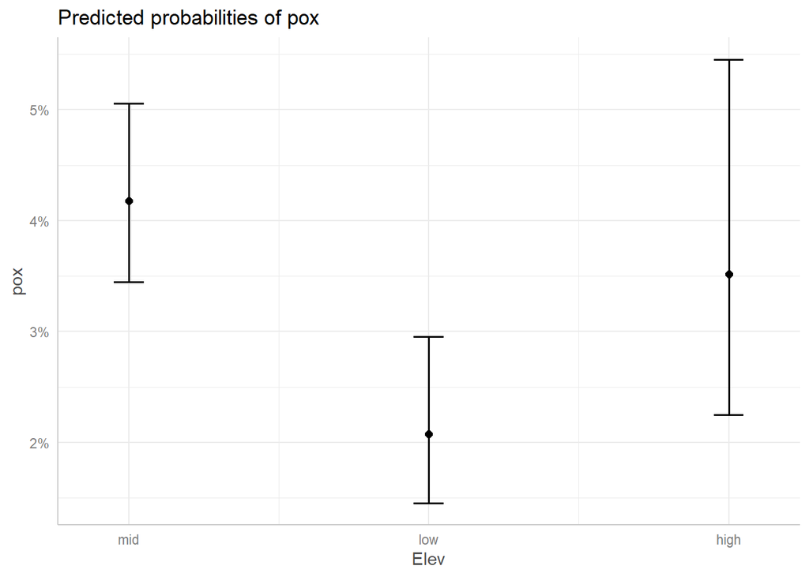

```r
plot(ggpredict(mod, terms ="Elev"))
```

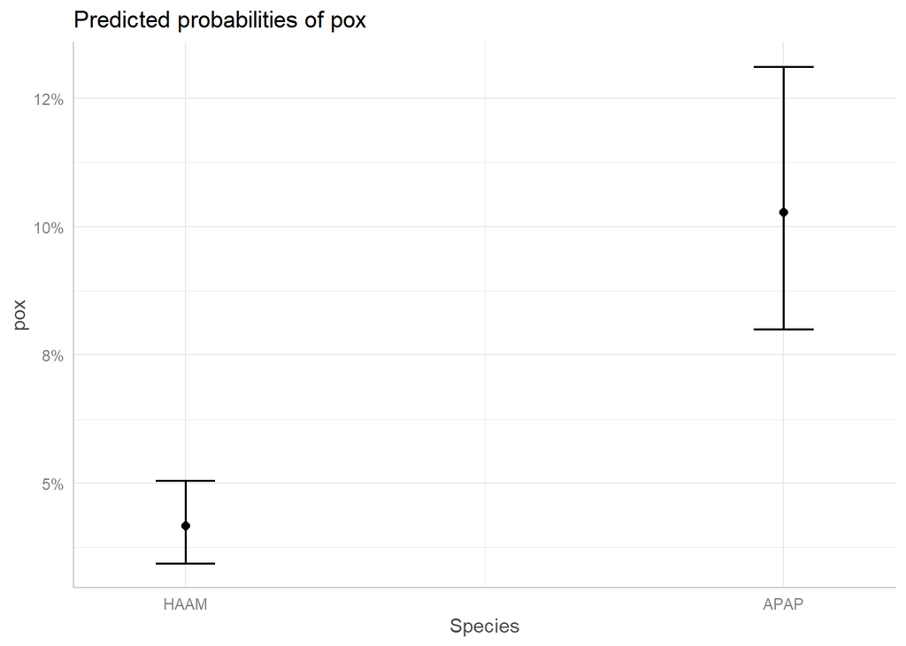

```r
plot(ggpredict(mod, terms ="Species"))
```

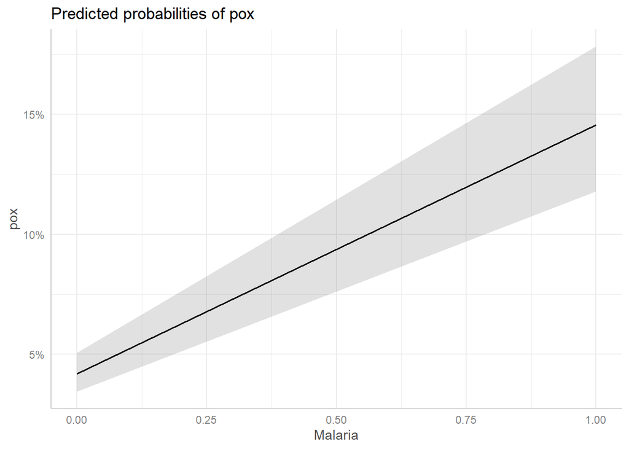

```r
plot(ggpredict(mod, terms ="Malaria"))
```

# 4 Do not pay attention to this

## 4.1 Answer

I began doing question 2 and 3 in a similar way to the boar-TB example in lecture notes 7. I created a data frame with total population, and infected population so that I could do a glm() with `family = binomial`, and ‘weights = population’ where ‘population’ is the total bird observation per species/elevation. I decided the way I did it above was probably closer to the correct answer although the answers end up being very similar. I do the same thing as above where one test is run with Iiwi and one test is run without Iiwi or unknown malaria data.

### 4.1.1 Dataframe

```r
birds  <- read.csv(paste(infile, "Pox_Data_revised.csv",
                         sep = ""))

birds$pox <- birds$Activepox + birds$Oldpox
birds[birds$pox == 2, "pox"] <- 1

birds$x <- rep(1, nrow(birds))
all_birds <- aggregate(birds$x,
                       by = list(Species = birds$Species, Elev = birds$Elev),
                       FUN = sum)

pox_birds <- aggregate(birds$pox,
                       by = list(Species = birds$Species, Elev = birds$Elev),
                       FUN = sum)

all_birds$pox <- pox_birds$x
all_birds$per_pox <- pox_birds$x/all_birds$x
colnames(all_birds) <- c("Species", "Elev", "pop", "pox", "per_pox")

mod = glm(per_pox ~ Species + Elev:Species,
          data    = all_birds,
          family  = binomial,
          weights = pop)

head(all_birds)
```

```
##   Species Elev  pop pox     per_pox
## 1    APAP high  839  22 0.026221692
## 2    HAAM high  623  20 0.032102729
## 3    IIWI high 1100  36 0.032727273
## 4    JAWE high  283   1 0.003533569
## 5    APAP  low    7   2 0.285714286
## 6    HAAM  low 1539  99 0.064327485
```

### 4.1.2 Summary Statistics

```r
summary(mod)
```

```
##
## Call:
## glm(formula = per_pox ~ Species + Elev:Species, family = binomial,
##     data = all_birds, weights = pop)
##
## Deviance Residuals:
##  [1]  0  0  0  0  0  0  0  0  0  0  0
##
## Coefficients: (1 not defined because of singularities)
##                     Estimate Std. Error z value Pr(>|z|)
## (Intercept)          -3.6146     0.2161 -16.730  < 2e-16 ***
## SpeciesHAAM           0.2084     0.3136   0.665  0.50630
## SpeciesIIWI           0.2283     0.2746   0.832  0.40567
## SpeciesJAWE          -2.0273     1.0248  -1.978  0.04790 *
## SpeciesAPAP:Elevlow   2.6983     0.8641   3.123  0.00179 **
## SpeciesHAAM:Elevlow   0.7289     0.2499   2.917  0.00354 **
## SpeciesIIWI:Elevlow       NA         NA      NA       NA
## SpeciesJAWE:Elevlow  -0.3471     1.4163  -0.245  0.80643
## SpeciesAPAP:Elevmid   2.8518     0.2241  12.728  < 2e-16 ***
## SpeciesHAAM:Elevmid   0.6357     0.2400   2.649  0.00808 **
## SpeciesIIWI:Elevmid   2.2877     0.5435   4.209 2.56e-05 ***
## SpeciesJAWE:Elevmid   1.4360     1.0150   1.415  0.15713
## ---
## Signif. codes:  0 '***' 0.001 '**' 0.01 '*' 0.05 '.' 0.1 ' ' 1
##
## (Dispersion parameter for binomial family taken to be 1)
##
##     Null deviance:  1.0579e+03  on 10  degrees of freedom
## Residual deviance: -3.3573e-13  on  0  degrees of freedom
## AIC: 72.873
##
## Number of Fisher Scoring iterations: 4
```

```r
Anova(mod, type = 2, test = "F")
```

```
## Analysis of Deviance Table (Type II tests)
##
## Response: per_pox
## Error estimate based on Pearson residuals
##
##              Sum Sq Df F value Pr(>F)
## Species      694.26  3       0    NaN
## Species:Elev 363.64  7       0    NaN
## Residuals      0.00  0
```

### 4.1.3 Effects Fiures

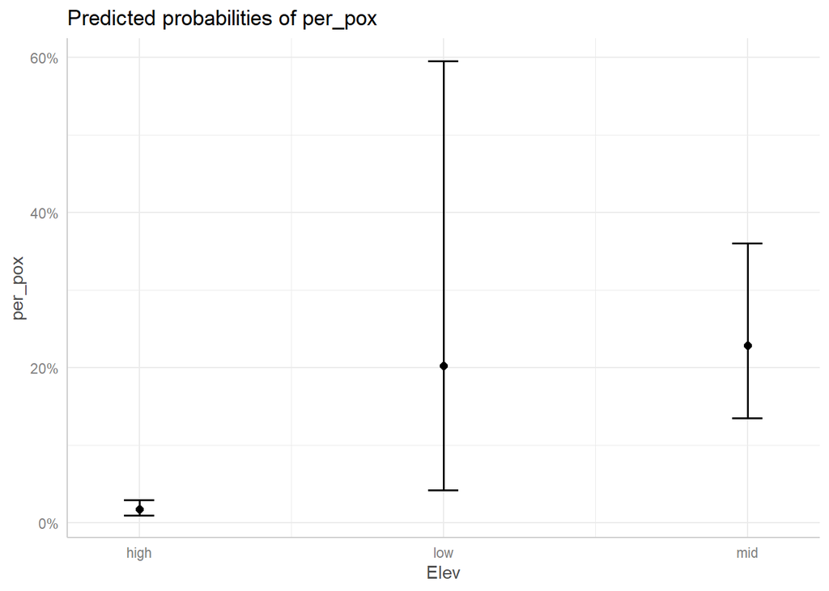

```r
plot(ggeffect(mod, terms ="Elev"))
```

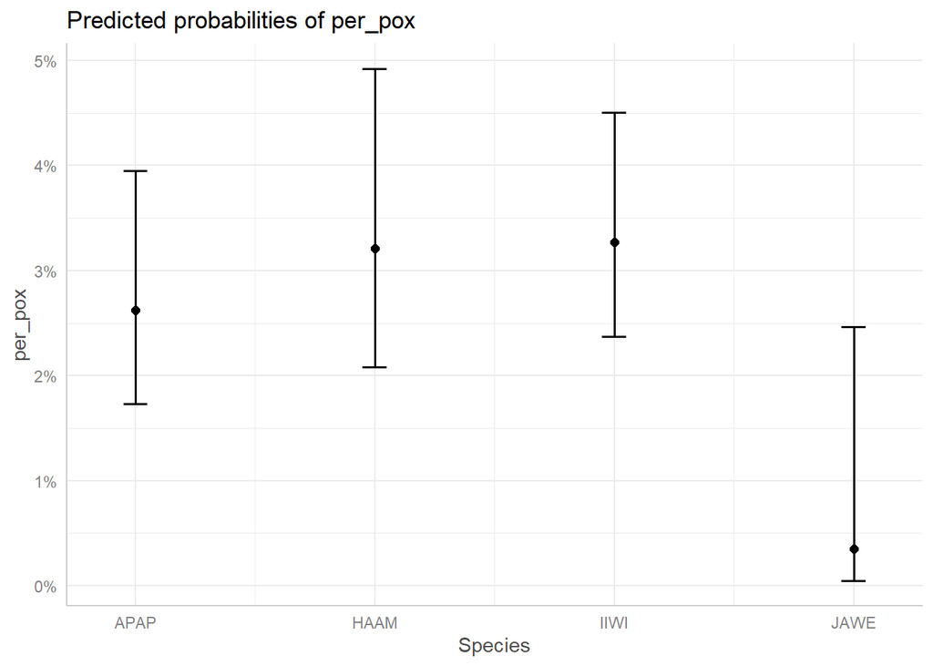

```r
plot(ggeffect(mod, terms ="Species"))
```

## 4.2 Answer

### 4.2.1 Dataframe

```r
birds  <- read.csv(paste(infile, "Pox_Data_revised.csv",
                         sep = ""))

birds[birds$Malaria == 2, "Malaria"] <- NA
birds <- subset(birds, !is.na(Malaria))
birds <- subset(birds, !Species == "IIWI")

birds$pox <- birds$Activepox + birds$Oldpox
birds[birds$pox == 2, "pox"] <- 1

birds$x <- rep(1, nrow(birds))
all_birds <- aggregate(birds$x,
                       by = list(Species = birds$Species, Elev = birds$Elev),
                       FUN = sum)

pox_birds <- aggregate(birds$pox,
                       by = list(Species = birds$Species, Elev = birds$Elev),
                       FUN = sum)

mal_birds <- aggregate(birds$Malaria,
                       by = list(Species = birds$Species, Elev = birds$Elev),
                       FUN = sum)

all_birds$mal <- mal_birds$x
all_birds$pox <- pox_birds$x
all_birds$per_mal <- mal_birds$x/all_birds$x
all_birds$per_pox <- pox_birds$x/all_birds$x
colnames(all_birds) <- c("Species", "Elev", "pop", "malaria","pox", "per_mal",
                         "per_pox")

mod = glm(per_pox ~ Species + Elev + Elev:Species + per_mal + per_mal:Species,
          data = all_birds,
          family = "binomial",
          weights = pop)
head(all_birds)
```

```
##   Species Elev  pop malaria pox    per_mal    per_pox
## 1    APAP high  735      58  20 0.07891156 0.02721088
## 2    HAAM high  515      10  19 0.01941748 0.03689320
## 3    APAP  low    7       6   2 0.85714286 0.28571429
## 4    HAAM  low 1330    1138  91 0.85563910 0.06842105
## 5    APAP  mid 1217     715 399 0.58751027 0.32785538
## 6    HAAM  mid 2767     486 166 0.17564149 0.05999277
```

### 4.2.2 Summary Statistics

```r
summary(mod)
```

```
##
## Call:
## glm(formula = per_pox ~ Species + Elev + Elev:Species + per_mal +
##     per_mal:Species, family = "binomial", data = all_birds, weights = pop)
##
## Deviance Residuals:
## [1]  0  0  0  0  0  0
##
## Coefficients: (2 not defined because of singularities)
##                     Estimate Std. Error z value Pr(>|z|)
## (Intercept)          -4.1024     0.2833 -14.482  < 2e-16 ***
## SpeciesHAAM           0.7109     0.3810   1.866  0.06207 .
## Elevlow              -2.5258     1.0445  -2.418  0.01560 *
## Elevmid              -0.5306     0.3715  -1.428  0.15326
## per_mal               6.6639     0.9673   6.889 5.62e-12 ***
## SpeciesHAAM:Elevlow  -2.3958     0.9251  -2.590  0.00961 **
## SpeciesHAAM:Elevmid       NA         NA      NA       NA
## SpeciesHAAM:per_mal       NA         NA      NA       NA
## ---
## Signif. codes:  0 '***' 0.001 '**' 0.01 '*' 0.05 '.' 0.1 ' ' 1
##
## (Dispersion parameter for binomial family taken to be 1)
##
##     Null deviance: 6.3070e+02  on 5  degrees of freedom
## Residual deviance: 3.1286e-13  on 0  degrees of freedom
## AIC: 44.453
##
## Number of Fisher Scoring iterations: 3
```

```r
Anova(mod, type = 2)
```

```
## Analysis of Deviance Table (Type II tests)
##
## Response: per_pox
##                 LR Chisq Df Pr(>Chisq)
## Species           1.5181  1    0.21791
## Elev              8.5173  2    0.01414 *
## per_mal                   0
## Species:Elev              0
## Species:per_mal           0
## ---
## Signif. codes:  0 '***' 0.001 '**' 0.01 '*' 0.05 '.' 0.1 ' ' 1
```

### 4.2.3 Effects Figures

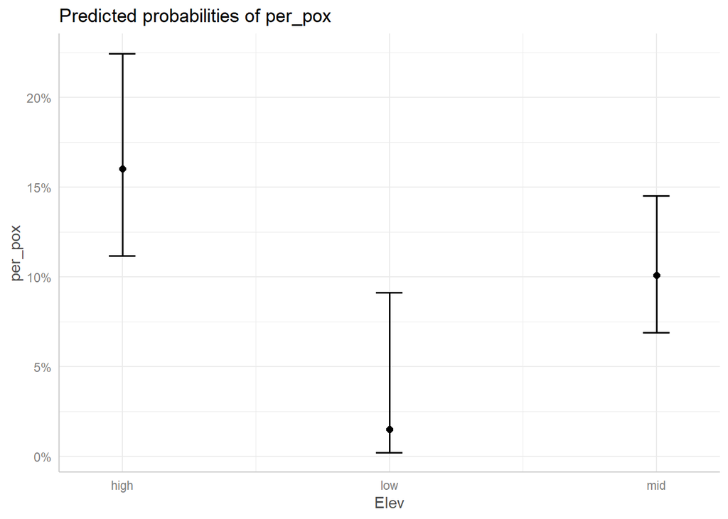

```r
plot(ggpredict(mod, terms ="Elev"))
```

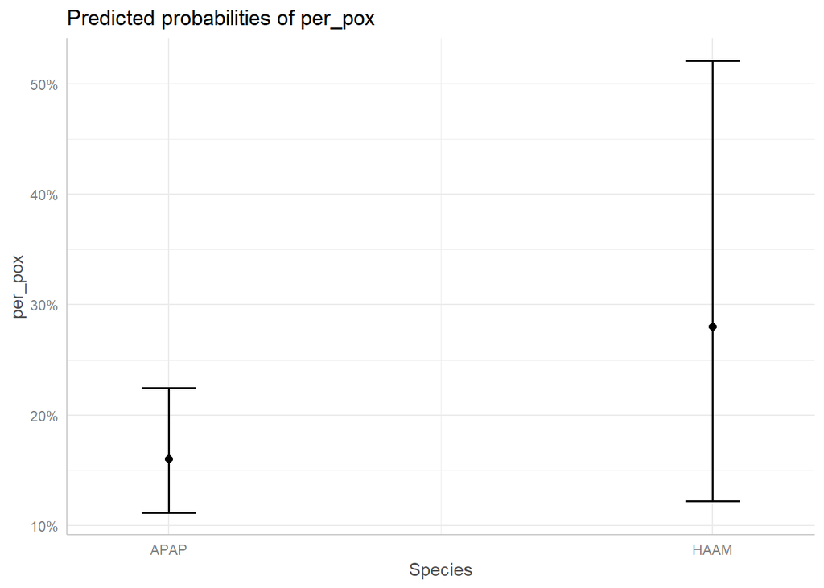

```r
plot(ggpredict(mod, terms ="Species"))
```

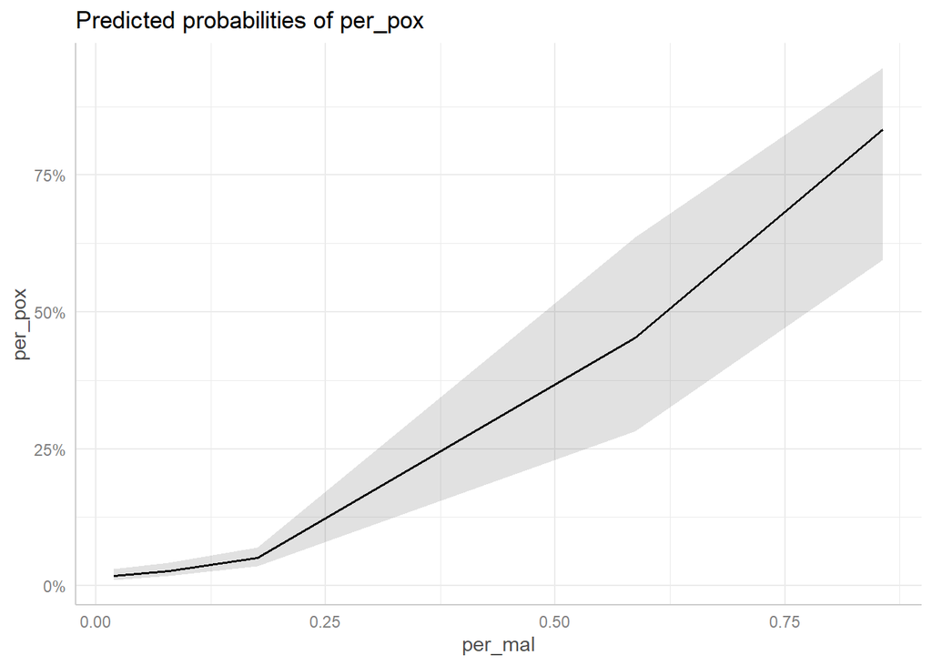

```r
plot(ggpredict(mod, terms ="per_mal"))
```